# [2019]_Горелов_Шарпей_I

# СОВРЕМЕННЫЕ ТЕХНОЛОГИИ ПРОГРАММИРОВАНИЯ: РАЗРАБОТКА WINDOWS-ПРИЛОЖЕНИЙ НА ЯЗЫКЕ С#

$$Том 1$$

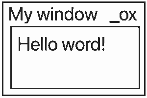

Страница 000

С. В. ГОРЕЛОВ

СОВРЕМЕННЫЕ ТЕХНОЛОГИИ ПРОГРАММИРОВАНИЯ: РАЗРАБОТКА WINDOWS-ПРИЛОЖЕНИЙ НА ЯЗЫКЕ С#

Учебник для студентов, обучающихся по дисциплине «Современные технологии программирования», направление «Прикладная информатика» (09.03.03 — для бакалавров, 09.03.04 — для магистров).

В двух томах. Однако. Чукча не читатель, чукча — писатель.

# Том-таки, слава богу, первый.

Москва 2019

Под научной редакцией доктора экономических наук Лукьянова Павла Борисовича.

УДК 004(075.8) ББК 32.973.26-018.1 Г68

Страница 001

**Автор**: **Сергей Витальевич Горелов** — кандидат технических наук, доцент Департамента анализа данных, принятия решений и финансовых технологий Финансового университета при Правительстве Российской Федерации.

**Рецензенты**: **Загородний В.И.** — доктор экономических наук, профессор Финансового университета при Правительстве Российской Федерации; **Волков А.Г.** — кандидат технических наук, доцент, начальник кафедры Военной академии РВСН им. Петра Великого.

# Горелов C.B.

Современные технологии программирования: разработка Windows-приложений на языке C#: Учебник. В 2 т. Т. 1 / С.В. Горелов; под науч. ред. П.Б. Лукьянова. — М.: Прометей, 2019. — 362 с.

В учебнике даются основные сведения о теории и практике разработки Windows-приложений с графическим интерфейсом на языке C#. Книга состоит из двух томов. В первом томе излагаются основы Windows Forms и рассматриваются наиболее популярные элементы управления и компоненты, изучаются способы привязки элементов управления к источникам данных, достаточно подробно анализируются формы и их взаимодействие.

При разработке приложений предпочтение отдается визуальной среде Visual Studio.

Соответствует требованиям Федерального государственного образовательного стандарта высшего образования последнего поколения.

Для студентов, имеющих практические навыки разработки консольных приложений на языке C# и продолжающих его изучение для создания приложений с графическим интерфейсом. Материал учебника может быть полезен студентам при выполнении курсовых работ и творческих домашних заданий. Может быть интересен аспирантам, научным сотрудникам и преподавателям.

ISBN 978-5-907100-09-1

Горелов С.В., 2019 Издательство «Прометей», 2019

Страница 002

# СОДЕРЖАНИЕ. Сразу с козырей зашёл, так сказать...

- 7 - Предисловие
- 10 - 1. Взаимодействие пользователя с программой
  - 10 - 1. Типы программ
  - 12 - 1.2. Цикл обработки сообщений
  - 14 - 1.3. Компоненты окна
- 16 - 2. Windows-приложения и среда Visual Studio.
  - 16 - 2.1. Среда Visual Studio
  - 32 - 2.2. Подробнее о делегатах и событиях
  - 32 – Делегаты
  - 33 – События
  - 36 - 2.3. Структура Windows-приложения.
- 45 - 3. Общие сведения об элементах управления
- 56 - 4. Часто используемые члены класса Control
  - 56 - 4.1. Свойства класса Control
  - 59 – 4.2. Методы класса Control
  - 61 – 4.3. События класса Control
- 65 - 5. Внедрение изображения в сборку
- 67 - 6. Диалоговое окно MessageBox
- 71 - 7. Программное управление интерфейсом
- 75 - 8. Элемент управления Button
- 81 - 9. Элемент управления Label
- 83 - 10. Элемент управления TextBox
- 98 - 11. Элемент управления MaskedTextBox
- 108 - 12. Группирование элементов. .
  - 108 - 12.1. Элемент управления GroupBox . .
  - 109 - 12.2. Элемент управления Panel .
- 110 - 13. Флажки и переключатели . . •
  - 110 - 13.1. Элемент управления CheckBox
  - 113 - 13.2. Элемент управления RadioButton
- 116 - 14. Регуляторы
  - 116 - 14.1. Элемент управления DomainUpDown
  - 119 - 14.2. Элемент управления NumericUpDown
- 123 - 15. Комплексный пример
- 126 - 16. Задания для самостоятельной работы

Страница 3

- 139 - 17. Списочные элементы управления
  - 139 - 17.1. Общие сведения
  - 155 - 17.2. Элемент управления ListBox
  - 159 - 17.3. Элемент управления ComboBox
  - 165 - 17.4. Элемент управления CheckedListBox
  - 170 - 17.5. Изменение объектов коллекции
  - 172 - 17.6. Задания для самостоятельной работы
- 175 - 18. Привязка к источнику данных
  - 175 - 18.1. Общие сведения
  - 177 - 18.2. Сложная привязка
    - 177 - Основные сведения
    - 188 - Перерисовка элемента управления
    - 191 - Режим визуальной привязки
    - 193 - BindingSource как самостоятельный источник данных
    - 195 - BindingNavigator
    - 197 - Фильтрация строк источника данных
    - 198 - Использование yield для формирования источника данных
    - 200 - Встроенные и ссылочные типы источника данных
  - 203 - 18.3. Простая привязка
    - 203 - Основные сведения
    - 207 - Примеры простой привязки
    - 209 - Простая привязка к сложному объекту
    - 212 - События класса Binding
    - 214 - Привязка в режиме визуальной разработки
  - 216 - 18.4. Комплексный пример
  - 221 - 18.5. Задания для самостоятельной работы
- 222 - 19. Главное и контекстное меню
  - 222 - 19.1. Главное меню ...
  - 229 - 19.2. Контекстное меню
  - 233 - 19.3. Задания для самостоятельной работы. .
- 234 - 20. Панель инструментов
  - 234 - 20.1. Общие сведения
  - 238 - 20.2. Практика использования компонента ToolStrip
  - 241 - 20.3. Пример использования ToolStrip
  - 244 - 20.4. Дополнительные возможности ToolStrip
  - 247 - 20.5. Задания для самостоятельной работы

Страница 4

Страница 5

- 339 - 27. Создание фоновых программ
  - 339 - 27.1. Общие сведения о компоненте Notifylcon
  - 341 - 27.2. Пример использования компонента NotifyIcon
  - 345 - 27.3. Задания для самостоятельной работы
- 346 - 28. Стандартные диалоговые окна
  - 346 - 28.1. Общие сведения
  - 347 - 28.2. Диалоговое окно открытия файла (OpenFileDialog)
  - 350 - 28.3. Диалоговое окно сохранения файла (SaveFileDialog)
  - 352 - 28.4. Диалоговое окно выбора папки (FolderBrowserDialog)
  - 355 - 28.5. Диалоговое окно выбора шрифта (FontDialog)
  - 357 - 28.6. Диалоговое окно выбора цвета (ColorDialog)
  - 358 - 28.7. Задания для самостоятельной работы
- 359 - Заключение
- 360 - Литература

Страница 6

# ПРЕДИСЛОВИЕ

Разработка приложений с графическим интерфейсом, кроме написания кода, включает в себя также проектирование и разработку интерфейса пользователя. Под интерфейсом пользователя понимаются окна приложения, их элементы управления и организация взаимодействия с пользователем. Качество интерфейса, его эргономика, художественное оформление и т.д. определяют качество и привлекательность приложения. Вспомним, сколько раз менялся интерфейс таких интернет-ресурсов, как портал государственных услуг (https://www.mos.ru/) или портал Финансового университета (www.fa.ru). Разработчики этих порталов предпринимают много усилий для того, чтобы сделать свой продукт удобным. **Наиболее эффективные** и развитые подходы к разработке Windows-приложений предлагает платформа Framework .NET и ее среда разработки Visual Studio. В этой платформе реализованы две технологии разработки интерфейса пользователя: Windows Forms и Windows Presentation Foundation (WPF). WPF является новой технологией, основанной на XML. Старая традиционная технология практически не требует знания языка XML, поэтому она проще новой. **В данном учебнике** излагаются основы разработки Windows-приложений по технологии Windows Forms. Эта технология представлена типами пространства имен System.Windows.Forms, к которым относятся элементы управления, компоненты, диалоговые окна и другие типы. **Среда Visual Studio** позволяет проектировать окна приложения в режиме визуальной разработки, при этом во многих случаях программисту не требуется разрабатывать код для корректировки интерфейса. Программист направляет свои усилия лишь на разработку обработчиков событий. При этом разработчик всё равно должен знать назначение, свойства и поведение элементов интерфейса и использовать наиболее подходящие элементы для решения задачи. Количество элементов управления и компонентов превышает 60. Подробно изучить их в одном учебнике не представляется возможным. В учебнике излагаются лишь наиболее часто используемые свойства и методы этих элементов, что в большинстве случаев не препятствует созданию приложения с развитым эргономичным интерфейсом. Все типовые применения элементов управления и компонентов проиллюстрированы примерами на языке С#.

Страница 7

Страница 8

В результате освоения дисциплины студенты должны **знать**: **во-первых**, назначение и свойства элементов управления и компонентов пользовательского интерфейса; **во-вторых**, основные способы использования элементов управления и компонентов пользовательского интерфейса; **в-третьих**, назначение и возможности интегрированной визуальной среды программирования; **в-четвертых**, возможности современных технологий, внедряемых в профессиональные приложения с использованием интегрированной среды программирования;

**Уметь**: **во-первых**, создавать эргономичный пользовательский интерфейс приложения; **во-вторых**, использовать элементы управления и компоненты пользовательского интерфейса при разработке приложений; **в-третьих**, использовать возможности интегрированной визуальной среды программирования; **в-четвертых**, использовать современные технологии при разработке профессиональных приложений; **в-пятых**, использовать средства языка программирования и визуальной среды для отладки программы;

**Владеть**: **во-первых**, навыками проектирования пользовательского интерфейса с использованием элементов управления и компонентов; **во-вторых**, навыками работы в интегрированной визуальной среде программирования при создании приложения; **в-третьих**, навыками реализации современных технологий в разрабатываемых профессиональных приложениях.

Страница 9

# 1. ВЗАИМОДЕЙСТВИЕ ПОЛЬЗОВАТЕЛЯ С ПРОГРАММОЙ.

## 1.1. Типы программ.

Существуют два типа прикладных программ (ПП), различающихся способом взаимодействия с Windows и свойствами создаваемого окна. Это консольные приложения и приложения с графическим интерфейсом. Для консольных приложений операционная система Windows создает окно, являющееся моделью окна MS DOS с текстовым режимом. Консоль состоит из окна и клавиатуры. Манипулятор «мышь» не поддерживается. **С появлением Windows** основными приложениями стали приложения с графическим интерфейсом. Такие приложения будем называть Windows-приложениями. **Консольная программа инициирует** взаимодействие с пользователем с помощью запросов на выполнение того или иного метода. На рис. 1.1 показана схема взаимодействия на примере ввода с клавиатуры с помощью метода System.Console.ReadLine. Консольная программа путем выполнения методов консольного ввода (запросов) определяет моменты времени и последовательность взаимодействия программы с пользователем. **Однако Windows-приложения** работают не так. Пользователь сам выбирает, какой элемент управления, размещенный на окне, он хочет использовать. Взаимодействие программы с пользователем берет на себя Windows. Прикладная программа теперь не запрашивает с помощью функций ввод данных, вместо этого она ждет, когда Windows известит программу о том, что пользователь выполнил какое-то действие. И к этим действиям относится не только ввод данных, но и огромное количество других действий, например выборка пункта меню. Этот процесс проиллюстрирован на рис. 1.2.

Страница 10

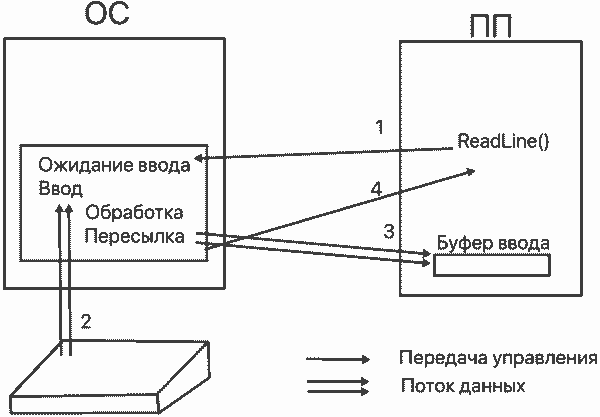

Рис. 1.1. Взаимодействие консольной программы с пользователем, управляемое запросами (функциями)

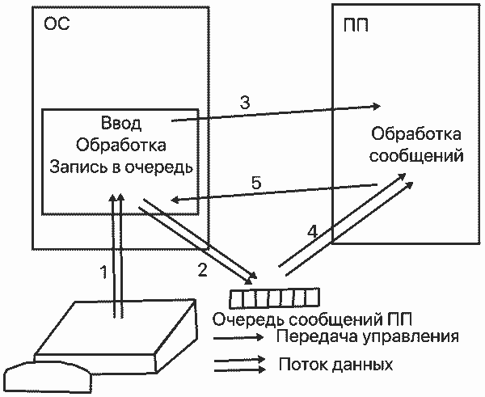

Рис. 1.2. Взаимодействие Windows-программы с пользователем, управляемое событиями

Программа ожидает сообщения, посылаемого ей операционной системой Windows. Сообщение передается в программу посредством вызова специальной функции, которая также выполняется системой Windows. После получения сообщения программа, как правило, выполняет запрограммированные действия. Взаимодействие программы и операционной системы, базирующееся на сообщениях, определяет схему построения всех Windows-программ. **В Windows существует** множество различных типов сообщений. Например, каждый раз при щелчке мыши в пределах окна программы ей будет направлено сообщение о нажатии кнопки мыши. Клавиатурное сообщение приходит, если нажата клавиша на клавиатуре в то время, когда окно программы имеет фокус ввода (т. е. ввод с клавиатуры направляется окну). Когда программа начинает работать, сообщения к ней приходят неупорядоченным образом, т. е. программа никогда «не знает», какое сообщение будет следующим. Таким образом, Windows-программы напоминают программы, работающие по прерываниям.

Страница 11

# 1.2. Цикл обработки сообщений.

Как отмечалось ранее, Windows взаимодействует с программой, посылая ей сообщения. При этом существует системная очередь сообщений — одна на всю систему и по одной очереди на каждый поток. На рис. 1.3 показана схема обработки событий, реализованная в Windows. **Системная очередь**, накапливая и перераспределяя сообщения по очередям потоков, решает задачи синхронизации. Все приложения Windows должны запускать цикл обработки сообщений. **В программах** на языке С++ цикл реализует разработчик в функции WinMain. В С#-программах такой цикл создается автоматически с помощью метода Application.Run. Этот метод в качестве параметра получает ссылку на главное окно программы. Цикл обработки сообщений выбирает сообщения из очереди сообщений приложения и направляет их обратно в Windows, которая затем вызывает оконную функцию программы, передавая ей указанные сообщения в качестве параметров. В программах на языке С++ оконная функция чаще всего имеет имя WndProc. Описанный способ взаимодействия может показаться излишне сложным, однако одной из причин реализации такой схемы является то, что программа должна возвращать управление планировщику Windows для распределения времени центрального процессора и его оптимальной загрузки.

Страница 12

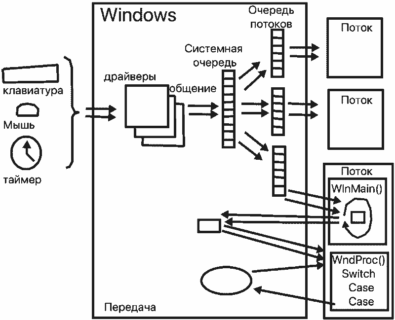

Рис. 1.3. Архитектура, управляемая событиями.

В программах на языке C# перечисленные выше аспекты реализации событийного управления скрыты внутри генерируемого кода. Разработчик освобожден от реализации цикла обработки сообщений и их анализа — управление сразу же передается соответствующему обработчику событий. Всё, что должен сделать разработчик, — это подписаться на нужное ему событие (будет рассмотрено ниже) и реализовать соответствующий этому событию обработчик. В обработчиках событий сосредотачивается основная функциональность Windows-приложения.

Страница 13

# 1.3. Компоненты окна.

Прежде чем приступить к обсуждению специальных аспектов программирования для Windows, необходимо определить несколько важных понятий. На рис. 1.4 отображено стандартное окно.

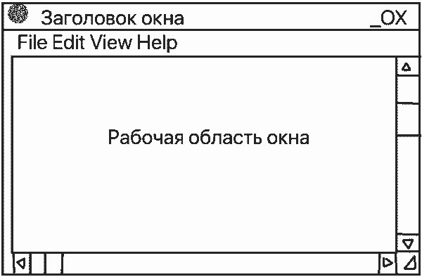

Рис. 1.4. Элементы стандартного окна Windows-приложения.

Все окна имеют рамку, которая определяет их границы; рамка используется также для изменения размеров окна. В верхнем левом углу окна находится значок системного меню. Щелчок мыши на этом значке открывает системное меню. Справа от иконки системного меню находится заголовок окна. В правом верхнем углу окна расположены кнопки минимизации, полноэкранной развертки (полноэкранного представления) и закрытия окна. **Рабочая область** — это часть окна, в которой отображается интерфейс пользователя и работа программы. Построение такого окна с его базовой функциональностью в С#-программах осуществляется автоматически. Разработчик может изменить многие стандартные настройки окна. Многие окна имеют также вертикальные и горизонтальные линейки прокрутки и меню.

Страница 14

$$***$$

Теперь, познакомившись с организацией событийного управления, перейдем к изучению среды визуальной разработки Windows-приложений — Visual Studio. Следует заметить, что на сегодняшний момент времени эта система является наиболее мощной из всех известных. Во многих случаях среда позволяет спроектировать оконный интерфейс приложения, не прибегая к ручному программированию. Visual Studio определяет вид проекта, создает для него решение с проектом и каркасные файлы, определяет подключаемые библиотеки и предоставляет пользователю элементы управления и компоненты, являющиеся инструментами пользовательского интерфейса.

Страница 15

# 2. WINDOWS-ПРИЛОЖЕНИЯ И СРЕДА VISUAL STUDIO.

### 2.1. Среда Visual Studio

Так как Windows-приложения, как правило, создаются в среде Visual Studio, то рассмотрим кратко окна этой программы, а затем структуру приложения, создаваемого в Visual Studio. Предполагается, что читатель освоил разработку консольных приложений в Visual Studio, поэтому мы опустим описание отдельных моментов. **Среда разработки Visual Studio** представляет собой полный набор средств разработки для создания настольных приложений, веб-приложений и мобильных приложений. Для создания настольного Windows-приложения в окне «Создание проекта» необходимо выбрать шаблон «Приложение Windows Forms» или шаблон «Приложение WPF» (см. рис. 2.1). Шаблон Windows Forms является традиционным, не требующим знаний языка XML, поэтому в данном томе сначала рассмотрим создание Windows-приложений в рамках этого шаблона. **Шаблон определяет** каркас приложения и структуру проекта, включая перечень библиотек DLL, типы которых могут быть использованы при разработке приложения. Основная библиотека проекта — System.Windows.Forms.dll. Введите для проекта имя WindowsFormsApp1. **После щелчка** кнопки ОК на экран будет выведено основное окно Visual Studio, состоящее из области меню и инструментов, строки состояния, а также пяти дочерних окон. Центральное окно — это окно Редактора. В этом окне отображается либо разрабатываемая форма, либо код программы. Форма — это окно на этапе проектирования. Окно называется формой, потому что оно является объектом класса Form, и оно служит контейнером для элементов управления пользовательского интерфейса. Любое окно, кроме окна Редактора, можно удалить или добавить, используя меню «Вид».

Страница 16

[figure not shown]

Рис. 2.1. Окно создания проекта.

Для того чтобы можно было предметно говорить о содержимом окон, создадим приложение для конвертирования рублей в доллары. Для этого раскроем окно «Панель элементов» и зафиксируем его на экране, нажав на кнопку = (Автоматически скрывать), расположенную в заголовке, возле кнопки «Закрыть». Далее перетащим на форму следующие элементы управления, расположив их один под другим (см. рис. 2.2): Label, TextBox, Button, Label, TextBox. Элементы типа Label будем использовать для отображения надписей (комментариев). Первый элемент TextBox будет предназначен для ввода вещественного числа — исходной суммы в рублях. По щелчку элемента Button будет запускаться метод для пересчета рублей в доллары. Отображаться сумма в долларах будет во втором элементе TextBox.

Страница 17

[figure not shown]

Рис. 2.2. Проектирование конвертора валют.

Другой способ перемещения элементов управления с панели на форму. Когда мы фиксируем панель элементов, она занимает часть окна Visual Studio, оставляя для формы меньшее пространство. Если же панель оставить плавающей, то после её отображения она перекроет часть формы. Если форма маленькая, то панель её может закрыть полностью. К сожалению, при перетаскивании элемента управления на форму панель не сворачивается. **Для того чтобы** убрать панель и открыть форму, можно поступить следующим образом. Щелкните нужный элемент и переместите курсор из панели на пустое окно редактора. Далее сделайте щелчок правой клавишей: панель свернется и откроется форма. Щелкните левой клавишей то место формы, где должен быть размещен верхний левый угол элемента управления — элемент появится на форме. **Для каждого элемента** управления на форме среда генерирует соответствующий объект, присваивая ему по умолчанию имя, совпадающее с именем элемента плюс порядковый номер элемента данного типа на форме. Часто в качестве начального текста (чтобы видеть элемент) используется имя объекта, например, первый элемент типа Label представлен в проекте объектом label1 с именем label1 и текстом «label1».

Страница 18

| Имя элемента управления | Значение свойства Text |
| --- | --- |
| button 1 | Конвертировать |
| label2 | Сумма в долларах: |

Страница 19

Для изменения значений других свойств могут использоваться списки или специальные окна. Чаще всего специальные окна используются тогда, когда значением свойства должен быть новый объект, созданный конструктором с несколькими параметрами. Для примера изменим шрифты элементов textBox1 и textBox2 на Verdana, полужирный, 10. Для этого выделим сначала элемент textBox1, а затем, не отменяя это выделение, выделим также и элемент textBox2. Выделить несколько элементов управления можно щелчком мыши с одновременно нажатой клавишей Ctrl. Далее найдем свойство Font и щелкнем появившуюся кнопку с тремя точками — на экране отобразится окно свойств шрифта. Установим новые значения (см. рис. 2.3).

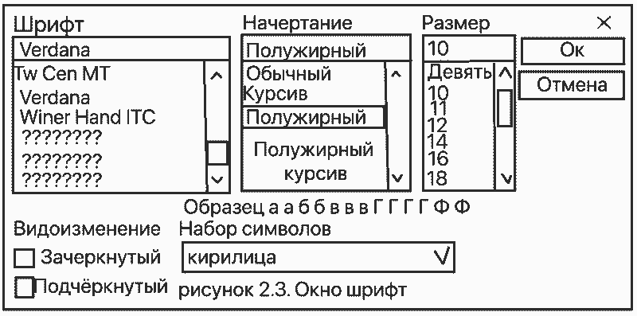

Рис. 2.3. Окно Шрифт

Выделять несколько элементов рекомендуется тогда, когда свойствам выделенных элементов присваиваются одинаковые значения. В нашем примере свойству Font элемента textBox1 и элемента textBox2 будет присвоен объект.

```
new Drawing.Font("Verdana", 10.2F, Drawing.FontStyle.Bold, Drawing.GraphicsUnit.Point, (byte)204);
```

Кнопка (Кнопка галочка вниз) (маркер) в строке свойства (см. рис. 2.2) также используется для вывода списка значений. Изменим цвет текста элемента label1 на красный, а label2 — на зеленый. Для этого выделим элемент label1, найдем свойство ForeColor и щелкнем кнопку (Кнопка галочка вниз). В появившемся окне во вкладке «Другой» выберите красный цвет (см. рис. 2.4). Точно так же для элемента label2 установите зеленый цвет текста.

Страница 20

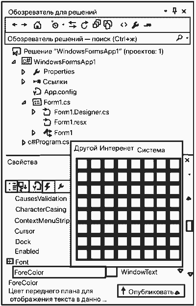

Рис. 2.4. Списки цветов.

И последнее: элемент TextBox предназначен не только для ввода данных, но и для их отображения, например, в элемент textBox2 мы будем выводить результат вычислений. Чтобы выведенное значение нельзя было изменить с клавиатуры, найдем свойство ReadOnly элемента textBox2 и присвоим ему значение True. На этом разработку интерфейса приложения будем считать законченной. На рис. 2.5 изображена спроектированная нами форма.

Страница 21

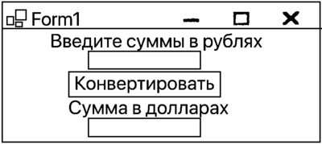

Рис. 2.5. Итоговый вид формы.

Выравнивание элементов. Для преодоления трудностей выравнивания элементов управления конструктор предоставляет такие средства, как «линии сетки» и «привязка линий». Вы можете изменять размеры многих элементов управления, используя маркеры и мышку. На панели «Макет» среды Visual Studio представлены 15 инструментов (см. рис. 2.6).

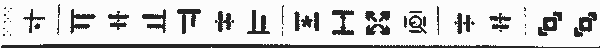

Эти инструменты позволяют выравнивать элементы управления относительно друг друга по вертикали, горизонтали, центру, правой границе и т.д. Для этого одновременно должны быть выделены два или более элемента управления. Для макетирования формы можно воспользоваться меню «Формат» (см. рис. 2.7).

Страница 22

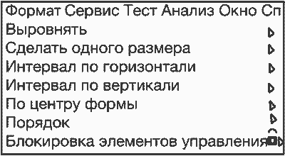

Рис. 2.7. Меню Формат

Это меню предоставляет больше возможностей (23) по сравнению с панелью «Макет». Когда элементы управления располагаются один под другим, их порядок — на передний план, на задний план — можно менять с помощью двух кнопок, примыкающих к правой границе панели «Макет» (см. рис. 2.6). **Для создания** специальных разметок формы, реагирующих на изменение размеров формы и элементов управления, можно также использовать элементы управления FlowLayoutPanel, TableLayoutPanel и SplitContainer. **Копирование элементов управления**. Если Вам нужно разместить на форме такой же элемент управления, как тот, который уже присутствует на форме, то можно воспользоваться операцией копирования элементов. Для этого щелчком правой кнопки выделите элемент (например, textBox1). Далее скопируйте элемент на новое место с помощью левой кнопки мыши, нажатой совместно с клавишей Ctrl или Shift. Новый элемент получит новое имя (textBox2), а все свойства останутся от исходного элемента. По сути дела, эта операция является размножением элемента управления. Наследование свойств от исходного элемента управления очень полезно — можно один раз установить требуемые свойства у элемента управления, а затем получать копии этого элемента с аналогичными свойствами. Следует заметить, что обработчики событий, созданные для исходного элемента управления, для новых элементов не копируются, а становятся общими для всех копий и исходного элемента. Обработчики событий будут рассмотрены ниже.

Страница 23

**Выполнение операций над группой элементов управления**. Установить значения общих свойств или выполнить форматирование можно сразу для нескольких элементов управления, для этого необходимо их выделить. Делается это щелчком левой кнопки мыши при нажатой на клавиатуре клавише Ctrl или Shift. После того как Вы выделите несколько элементов, можно установить их общие свойства или изменить размер. Если выделяемые элементы находятся в одной прямоугольной области формы, то можно выделить эту область, перемещая курсор при нажатой левой кнопке мыши. Естественно, выделится не область, а все элементы управления, хотя бы частично попавшие в эту область.

**Обработчики событий**. Интерфейс нашего приложения готов, и мы можем, сгенерировав сборку, выполнить ее. Однако сколько бы мы ни нажимали на кнопку «Конвертировать», никаких изменений не произойдет. Не раскрывая тонкостей, создадим метод, который будет получать управление каждый раз, когда пользователь будет нажимать на кнопку button 1. Для этого дважды щелкнем левой кнопкой мыши кнопку «Конвертировать», и Вам будет предоставлен каркас указанного метода для его наполнения соответствующим кодом. Такой метод называется обработчиком события. Созданный каркас обработчика события будет иметь следующий вид:

```
private void button1_Click(object sender, EventArgs e){}
```

Страница 24

Как мы видим, имя обработчика состоит из двух частей: имени элемента управления (компонента) и имени события. По двойному щелчку элемента управления среда создаёт пустой обработчик для так называемого события по умолчанию. Для большинства элементов управления, как, например, для Button, событием по умолчанию является событие Click. **Параметры обработчика** для отдельных событий, например Click, практически не используются. Однако для других событий эти параметры несут полезную информацию. Первый параметр описывает элемент управления (компонент), возбудивший событие, а второй — само событие. **Реализуем обработчик button1_Click**. Исходным значением для конвертирования является строка из textBox1, которая должна содержать вещественное число, следовательно, эту строку необходимо преобразовать в число. В качестве текущего курса для упрощения кода возьмем 50 рублей за 1 доллар. Вычисленное и преобразованное в строку число будем записывать в textBox2.

Приведем код обработчика button1_Click:

```
float curs = 50.0f;

private void button1_Click(object sender, EventArgs e)
{
    float rubli, dollars;
    if (!float.TryParse(textBox1.Text, out rubli))
    {
        MessageBox.Show("неправильно введена сумма в рублях!");
        textBox1.Focus();
        return;
    }
dollars = rubli / curs;
textBox2.Text = dollars.ToString();
```

}

Создадим сборку и запустим ее на выполнение. Введем сумму 800 рублей и нажмем кнопку «Конвертировать». В результате возникнет событие Click, и обработчик button1_Click получит управление. После выполнения обработчика окно программы будет выглядеть как на рисунке 2.8.

Страница 25

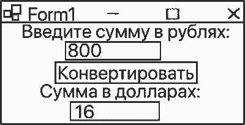

Рис. 2.8. Окно приложения

Подробнее о добавлении обработчиков событий. Не вдаваясь в подробности, отметим, что созданию обработчика события предшествует этап подписки на это событие. Для того чтобы подписаться на требуемое событие какого-либо элемента управления и создать обработчик события, в общем случае необходимо: **во-первых**, узнать, какое имя имеет событие; **во-вторых**, выяснить, какой делегат представляет событие, и по делегату определить формат заголовка обработчика события; **в-третьих**, подписаться на событие, то есть добавить обработчик к событию; **в-четвёртых**, создать пустой обработчик события с требуемыми параметрами; **в-пятых**, разработать тело обработчика события. **Перечисленные выше шаги** соответствуют модели событийного управления, реализованного в Windows. Выполнение их вручную — достаточно сложный для начинающего разработчика процесс, однако среда Visual Studio первые четыре шага выполняет автоматически в ответ на Ваши действия мышкой. По двойному щелчку элемента управления среда разработки подпишется на событие по умолчанию и предоставит Вам пустой обработчик для его наполнения кодом. Для большинства элементов управления событием по умолчанию, как было отмечено выше, является событие Click. Необходимо также отметить, что обработчик события — это обычный метод языка. Если дважды щелкнуть элемент управления textBox1, то будет создан следующий обработчик:

```
private void textBox1_TextChanged(object sender, EventArgs e){}
```

Страница 26

Как мы видим, событием по умолчанию здесь является TextChanged. Это событие происходит каждый раз, когда изменяется свойство Text элемента, то есть текста, отображаемого на поверхности textBox1. Параметры ender и e для этого события, как правило, разработчиком не используются, так как они не несут полезной информации. Однако ряд других событий в качестве второго параметра передают обработчикам ценные данные. Например, для события MouseClick заголовок обработчика выглядит следующим образом:

```
private void textBox1_MouseClick(object sender, MouseEventArgs e)
```

Параметр e здесь описывает, какая кнопка мыши была нажата и в каких координатах находится курсор. А как быть, если мы хотим обработать событие, отличное от события по умолчанию? Для этого выполним следующие действия: **во-первых**, выделим элемент управления; **во-вторых**, в окне «Свойства», на панели инструментов, щелкнем кнопку (Кнопка со значком молнии), раскрывающую окно «События»; **в-третьих**, в отображенном списке найдём нужное событие (см. рис. 2.9); **в-четвёртых**, щелкнем событие дважды или выберем обработчик из списка ранее созданных. Каждая строка в списке событий имеет две части: имя события и имя обработчика этого события. Двойной щелчок строки приводит к автоматическому выполнению вышеперечисленных четырех этапов для этого события.

Страница 27

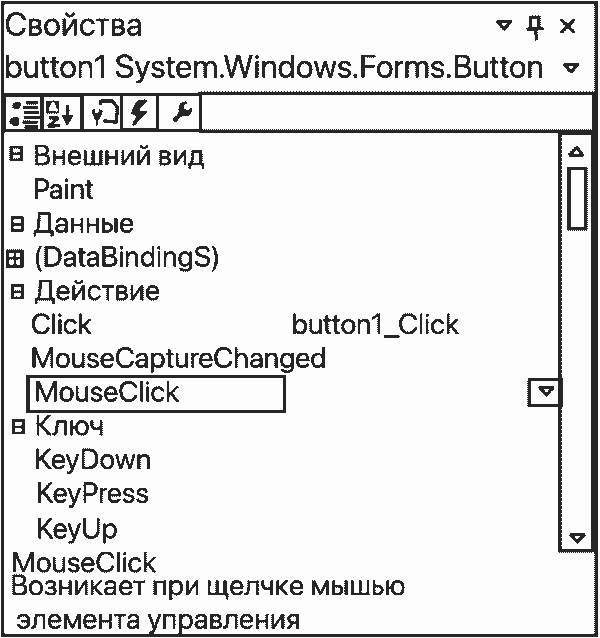

Рис. 2.9. Список событий элемента управления button1.

При выделении события в правой части строки появляется кнопка (кнопка в форме галочки вниз) для выбора обработчика из списка ранее созданных обработчиков. Это позволяет разные события обработать с помощью одного и того же обработчика (здесь может пригодиться первый параметр обработчика). Кроме того, для одного и того же события можно определить несколько разных обработчиков, выполняемых последовательно, но делать это придется вручную. Есть как минимум два способа подключения второго и последующих обработчиков к одному событию:

Страница 28

1.Можно из одного обработчика вызвать другой, например:

```
private void textBox1_TextChanged(object sender, EventArgs e)
{
    //...
    button1_Click(sender, e);
    //...
}
```

Если параметры вызываемого обработчика события не совпадают с параметрами текущего и не используются в вызываемом обработчике, то можно использовать значение null, например:

```
button1_Click(null, null);
```

Данный способ хорош тем, что Вы сами определяете, в каком месте Вам вызвать другой обработчик, и этот другой обработчик может иметь параметры любого типа.

Странице 29

2.Можно добавить к событию еще один или несколько обработчиков. Для этого нужно открыть файл Form1.Designer.cs, найти фрагмент кода, созданного для выбранного элемента управления, и в этом фрагменте найти строку с событием, добавленной в автоматическом режиме (как правило, последняя строка). Например, для элемента управления textBox1 сгенерированный в нашем примере код будет выглядеть следующим образом (без this):

```
//
// textBox1
//
textBox1.Font = new System.Drawing.Font("Verdana", 10.2F, System.Drawing.FontStyle.Bold, System.Drawing.GraphicsUnit.Point, (byte)204);
textBox1.Location = new System.Drawing.Point(79, 48);
textBox1.Name = "textBox1";
textBox1.Size = new System.Drawing.Size(100, 28);
textBox1.TabIndex = 1;
textBox1.TextChanged += new System.EventHandler(textBox1_TextChanged);
```

Последняя строка приведённого фрагмента определяет подписку на событие TextChanged элемента textBox1 с помощью обработчика textBox1_TextChanged.

Класс EventHandler является групповым делегатом, определяющим, сколько параметров и какого типа должно быть определено в заголовке нашего обработчика. Наведите курсор на имя делегата (EventHandler), и Вы получите оперативную справку по формату заголовка обработчика. Для получения более подробной информации можно воспользоваться справочной системой. В принципе, никакой дополнительной информации нам не нужно, так как подключаемый обработчик должен иметь точно такие же параметры, как и созданный ранее автоматически. Добавим обработчик button1_Click, для этого допишем к приведённому выше фрагменту следующую строку:

```
textBox1.TextChanged += new System.EventHandler(button1_Click);
```

Обработчики будут получать управление в порядке их добавления: сначала textBox1_TextChanged, а затем button1_Click. Допускается более короткая запись:

```
textBox1.TextChanged += button1_Click;
```

Страница 30

Отмена привязки обработчика к событию. Чтобы на этапе визуальной разработки отменить привязку обработчика к событию, достаточно стереть его имя справа от события в окне событий. Отменить регистрацию на этапе выполнения можно, используя составную операцию -=, например:

```
textBox1.TextChanged -= new System.EventHandler(button1_Click);
```

Или так:

```
textBox1.TextChanged -= button1_Click;
```

Поскольку не рекомендуется изменять файл Form1.Designer.cs, можно добавить обработчики в конструкторе формы после её инициализации, например:

```
public Form1()
{
    InitializeComponent();
    textBox1.TextChanged += new System.EventHandler(button1_Click);
}
```

Как мы уже поняли, можно использовать короткий формат создания экземпляра делегата, опустив new и имя делегата, например:

```
public Form1()
{
    InitializeComponent();
    textBox1.TextChanged += button1_Click;
}
```

Замечание: во всех примерах используется имя формы Form1, однако эти примеры справедливы для формы с любым именем.

Страница 31

# 2.2. Подробнее о делегатах и событиях

Если для управления событиями в приложениях с графическим интерфейсом Вам достаточно приведённой выше информации, то данный раздел можно пропустить. Ниже речь пойдёт об углублённом описании понятий делегат и событие применительно к Windows-приложениям.

# ДЕЛЕГАТЫ

В событийной модели используются групповые (многоадресатные) делегаты. Делегат — это класс, содержащий данные о том, какую сигнатуру должен иметь метод, указываемый в экземпляре этого класса. В экземпляре можно определить только тот метод, у которого тип возвращаемого значения (в случае событийной модели — void) и список параметров совпадают с соответствующими элементами объявления делегата. Информация, описывающая заголовок метода, называется сигнатурой. В экземпляре делегата хранится ссылка на конкретный метод, поэтому вызов на выполнение экземпляра равносилен вызову метода. Общая форма объявления группового делегата:

```
delegate void имя_делегата (список_параметров);
```

Пусть групповой делегат MyDlg объявлен следующим образом: delegate void MyDig(int a, bool b); тогда в экземпляре этого делегата в качестве параметра можно указать имя следующего метода:

```
void Method (int sum, bool fl){/*...*/}
```

Страница 32

Это допустимо, так как сигнатура метода Method соответствует делегату MyDIg. Экземпляр делегата для метода Method создается так же, как и любой объект, например

```
MyDig Handler = new MyDIg (Method);
```

В качестве параметра конструктора указывается вызываемый метод. Поскольку этот метод будет вызывать система, то такой метод называется методом обратного вызова. Как было указано ранее, существует более простой способ создания экземпляра делегата, когда указывается только имя метода, например:

```
MyDIg Handler = Method;
```

# СОБЫТИЯ

Событийная модель в CLR строится на основе групповых делегатов. В событийной модели применяется схема «издатель-подписчик». В этой модели в различных источниках используются термины: издатель, подписчик, уведомление, подписка, регистрация, открепление и др. В данном учебнике для упрощения материала, по возможности, будут использоваться понятия из языка С#. **На уровне Windows** аппаратные события возникают от клавиатуры, мышки и таймера. В классах различных элементов управления присутствуют методы, создающие программные события, например «потеря элементом фокуса ввода». В языке С# событие представлено членом класса, который объявляется с помощью ключевого слова event. Синтаксис наиболее распространенной формы объявления события имеет следующий вид:

```
event имя делегата имя_события;
```

Из этого формата следует, что событие объявляется на основе созданного ранее группового делегата. Приведем пример объявления события Click класса Button:

```
public event EventHandler Click;
```

Страница 33

Из примера следует, что в элементе управления типа Button определено событие Click, которому может быть присвоен экземпляр делегата System.EventHandler с соответствующим по сигнатуре обработчиком события. Эта операция называется подпиской на событие. Например, по двойному щелчку элемента button1 среда Visual Studio сгенерирует (в Form1.Designer.cs) следующую подписку:

```
button1.Click += new System.EventHandler(button1_Click);
```

Также в Form1.cs будет сгенерирован пустой обработчик button1_Click. Сигнатура этого обработчика будет соответствовать делегату System.EventHandler. В каждом элементе управления определено множество событий. В визуальном режиме (в окне «Свойства») разработчик может выбрать событие, возникновение которого необходимо обрабатывать, и двойным щелчком или путем выборки старого обработчика выполнить подписку. Иногда разработчику требуется выполнить подписку на событие в том месте кода, где ему это необходимо. В этом случае он может использовать упрощенный синтаксис, например, для вышеприведенного примера такая подписка будет выглядеть следующим образом:

```
button1.Click += button1_Click;
```

Страница 34

Если обработчик события имеет маленький размер, то его тело можно перенести в лямбда-выражение, например:

```
button1.Click += (sender, args) => Close();
```

В этом случае анонимный обработчик события будет создан автоматически. Составные операции «+=» и «-=» позволяют добавлять ссылки на методы в экземпляр группового делегата и, соответственно, удалять их оттуда. Вызов события на выполнение приводит к последовательному вызову всех методов, ссылки на которые хранит экземпляр группового делегата. Вызов экземпляра также приводит к выполнению методов списка. Таким образом, член event — это дополнительный слой программного обеспечения. Такие методы называются обработчиками событий. **В классах**, представляющих элементы управления, определение событий и их вызов на выполнение осуществляется в методах, имя которых начинается с On. Так, определение события `Click` и вызов его обработчиков выполняется методом `OnClick`, а события `Enter` — методом `OnEnter`. Методы On... вызываются либо программно, либо при возникновении вложенного события более низкого уровня. Если переопределить или заместить метод On..., добавив свою обработку события, которое он вызывает, то необходимость в подписке на это событие отпадает. Приведем пример. Пусть необходимо выдать сообщение в случае щелчка формы Form1, не подписываясь на событие Click:

```
protected override void OnClick(EventArgs e)
{
    MessageBox.Show("Для формы не определена обработка события Click!*);
    base.OnClick(e);
}
```

Есть одно ограничение: все методы On... защищены (Protected) и вызвать их можно только из производного класса, которым, например, является класс Form1. Однако необходимость использования методов On... возникает редко. **И последнее**. Если Вы будете реализовывать свою событийную модель в приложении, то можно отказаться от членов event и использовать в классе только экземпляры групповых делегатов. Причина, по которой для классов был введен член event, для читателя неочевидна. Разные авторы часто указывают на повышение безопасности. В частности, есть мнение, что дело заключается в том, что экземпляр группового делегата (как и многие объекты) имеет методы, с помощью которых пользователь может повлиять на чужие ссылки на методы. Событие же не является объектом и поэтому не имеет каких-либо методов. Удалим из разрабатываемого нами приложения лишние подписки и методы, созданные в качестве примеров. Рассмотрим файловый состав и код приложения.

Страница 35

# 2.3. Структура Windows-приложения.

После того как мы выяснили, что такое делегат, событие и обработчик события, мы можем рассмотреть сгенерированный код. Сначала рассмотрим, как классы проекта распределяются по файлам. К числу исходных файлов с кодом на языке С# относятся файлы с расширением cs. Из рис. 2.10 следует, что это файлы Program.cs, Form1.cs и Form1.Designer.cs. Остальные файлы, не считая библиотек, не содержат выполнимого кода. **Примечание**. Следует заметить, что имена описанных в программе пользовательских классов, пространств имен и файлов могут быть изменены разработчиком по его усмотрению. Мы же будем использовать имена, генерируемые средой по умолчанию. Первый файл приложения, созданный автоматически, — это Program.cs. В этом файле определен метод Main, который первый получает управление (точка входа). Основная функция, которую выполняет метод Main, — это создание главного окна программы и запуск цикла обработки сообщений с помощью метода Run:

```
Application. Run(new Form1());
```

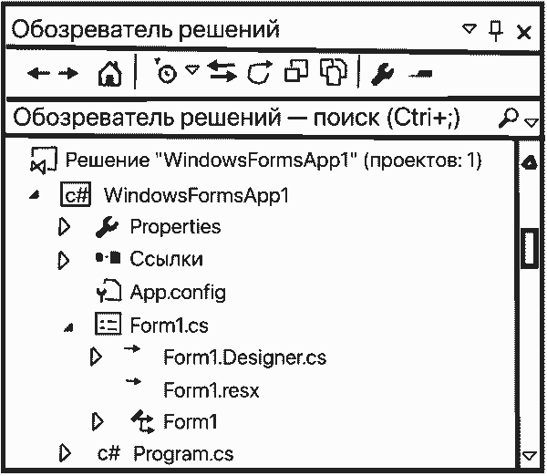

Рис. 2.10. Структура проекта WindowsFormsApp1

Вот как выглядит содержимое файла Program.cs:

```
using System;
using System.Collections. Generic;
using System.Linq;
using System.Threading. Tasks;
using System.Windows.Forms;

namespace WindowsFormsApp1
{
    static class Program
    {
        [STAThread]
        static void Main()
        {
            Application.EnableVisualStyles();
            Application.SetCompatibleTextRenderingDefault(false);
            Application.Run(new Form1());
        }
    }
}
```

В методе Мап с помощью оператора new Form1() создается экземпляр класса Form1, который определяет главное окно программы. Оператор '''new Form1()''' запускает на выполнение конструктор формы, с которого и начинается выполнение кода, созданного разработчиком совместно со средой Visual Studio. **Класс Form1** является пользовательским классом, наследующим у системного класса Form. Класс Form1 предназначен для добавления на форму элементов управления, изменения их свойств и определения обработчиков событий. Этот класс определен как состоящий из частей (partial). Разбит он на два файла: Form1.cs — часть разработчика и Form1.Designer.cs — часть, генерируемая средой в режиме визуальной разработки. Содержимое нашего файла Form1.cs:

```
using System;
using System.Collections.Generic;
using System.ComponentModel;
using System.Data;
using System.Drawing;
using System.Linq;
using System.Text;
using System.Threading.Tasks;
using System.Windows.Forms;
```

```
namespace WindowsFormsApp1
{
    public partial class Form1: Form
    {
        float curs = 50.0f;
        public Form1() { InitializeComponent(); }
        private void button1_Click(object sender, EventArgs e)
        {
            float rubli, dollars;
            if (!float.TryParse(textBox1.Text, out rubli))
            {
                MessageBox.Show( "неправильно введена сумма в рублях!");
                textBox1.Focus();
                return;
            }
            dollars = rubli / curs;
            textBox2.Text = dollars.ToString();
        }
    }
}
```

Рассмотрим конструктор класса Form1:

```
public Form1() { InitializeComponent(); }
```

Конструктор запускает инициализацию элементов управления и компонентов. Элементы управления объединяются в коллекцию формы. В файле Form1.cs нашей программы определен один обработчик события Click, генерируемого в результате нажатия кнопки button1:

```
private void button1_Click(object sender, EventArgs e)
```

Поля класса Form1, определенные разработчиком (в нашем случае float curs = 50.0f;), чаще всего размещаются перед конструктором, но их можно размещать и перед определением методов класса, включая обработчики событий. Файл Form1.Designer.cs генерируется конструктором, и поэтому не рекомендуется изменять его содержимое с помощью редактора кода. Этот файл может быть связан с другими файлами, например файлами ресурсов. Иногда в результате некорректных действий разработчика перестает отображаться форма. Чтобы решить эту проблему, приходится корректировать файл Form1.Designer.cs с целью устранения ошибки. Для выполнения такой работы бывает полезным знание генерируемого средой кода. Кроме того, файл Form1.Designer.cs демонстрирует примеры работы со свойствами элементов управления, что является ценным подспорьем при изучении элементов управления, компонентов и диалоговых окон.

Часто те или иные свойства элементов управления приходится изменять в обработчиках событий. Если Вы не знаете, как это сделать, тогда сначала измените нужное свойство в окне «Свойства». Посмотрите, какую строку в ответ на Ваши действия сгенерировал конструктор среды в файле Form1. Designer. cs. Этот код, как правило, и следует написать в обработчике события. Приведем содержимое файла Form1.Designer.cs нашего приложения с некоторыми упрощениями, которые сокращают текст и не вносят ошибок:

```
using System.Windows.Forms;
using System.Drawing;
using System.ComponentModel;

namespace WindowsFormsApp1
{
    partial class Form1
    {
        /// <summary> Обязательная переменная конструктора. </summary>
        Private IContainer components = null;

        /// <summary> Освободить все используемые ресурсы. </summary>
        /// <param name="disposing">истинно, если управляемый ресурс
        /// должен быть удален; иначе ложно. </param>
        Protected override void Dispose(bool disposing)
        {
            if (disposing && (components != null))
            { components.Dispose(); }
            base.Dispose(disposing);
        }
```

```
        #region Код, автоматически созданный конструктором
        /// <summary> Требуемый метод для поддержки конструктора
        /// - не изменяйте содержимое этого метода
        /// с помощью редактора кода. </summary>

        private void InitializeComponent()
        {
            label1 = new Label();
            textBox1 = new TextBox();
            button1 = new Button();
            label2 = new Label();
            textBox2 = new TextBox);
            SuspendLayout();
```

```
            //
            // label1
            //
            label1.AutoSize = true;
            label1.ForeColor = Color. Red;
            label1.Location = new Point(55, 28);
            label1.Name = "label1" ;
            label1.Size = new Size(170, 17);
            label1.TabIndex = 0;
            label1.Tag = "";
            label1.Text = "Введите сумму в рублях:";
```

```
            //
            // textBox1
            //
            textBox1.Font = new Font( "Verdana"
                , 10.2F
                ,FontStyle.Bold
                , GraphicsUnit.Point
                , (byte)204
            );
            textBox1.Location = new Point(79, 48);
            textBox1.Name = "textBox1";
            textBox1.Size = new Size(100, 28);
            textBox1.TabIndex = 1;
            textBox1.TextChanged += textBox1_TextChanged;
```

```
            //
            // button1
            //
            button1.Location = new Point(61, 95);
            button1.Name = "button1";
            button1.Size = new Size(131, 30);
            button1.TabIndex = 2;
            button1.Text = "Конвертировать" ;
            button1.UseVisualStyleBackColor = true;
            button1.Click += button1_Click;
```

```
            //
            // label2
            //
            label2.AutoSize = true;
            label2.ForeColor = Color.Green;
            label2.Location = new Point(66, 142);
            label2.Name = "label2" ;
            label2.Size = new Size(131, 17);
            label2.TabIndex = 3;
            label2.Text = "Сумма в долларах:";
```

```
            //
            // textBox2
            //
            textBox2.Font = new Font(
                "Verdana"
                ,  10.2F
                , FontStyle.Bold
                , GraphicsUnit.Point
                , (byte)204
            );
            textBox2.Location = new Point(79, 162);
            textBox2.Name = "textBox2";
            textBox2.ReadOnly = true;
            textBox2.Size = new Size(100, 28);
            textBox2.TabIndex = 4;
```

```
            //
            // Form1
            //
            AutoScaleDimensions = new SizeF(8F, 16F);
            AutoScaleMode = AutoScaleMode.Font;
            ClientSize = new Size(282, 253);
            Controls.Add(textBox2);
            Controls.Add(label2);
            Controls.Add(button1);
            Controls.Add(textBox1);
            Controls.Add(label1);
            Name = "Form1";
            Text = "Form1" ;
            ResumeLayout(false);
            PerformLayout();
        }
        #endregion
```

```
        private Label label1;
        private TextBox textBox1;
        private Button button1;
        private Label label2;
        private TextBox textBox2;
    }
}
```

В конце файла Form1.Designer.cs определены переменные для хранения ссылок на элементы управления и компоненты, добавленные нами на форму. Эта часть класса Form1 имеет два метода: во-первых, Dispose — удаление управляемых ресурсов; во-вторых, InitializeComponent — тело конструктора Form1. В начале метода InitializeComponent создаются экземпляры элементов управления и компонентов, а затем для каждого объекта инициализируются его свойства. В конце этого метода, в разделе Form1, инициализируются свойства формы и в ее коллекцию добавляются элементы управления.

$$* * *$$

Подводя итог, отметим: в этом разделе мы познакомились с внутренними окнами Visual Studio; разработали простейшее приложение; изучили, как организовано событийное управление; узнали, что такое делегат, событие и обработчик события; рассмотрели файловый состав нашего приложения и сгенерированный КОД. В следующем разделе перейдём к изучению общих сведений об элементах управления.

# 3. ОБЩИЕ СВЕДЕНИЯ ОБ ЭЛЕМЕНТАХ УПРАВЛЕНИЯ.

Почти все элементы управления наследуют класс Component, поэтому они являются компонентами. Класс Component предоставляет базовую реализацию интерфейса IComponent и делает возможным совместное использование объектов разными приложениями. При этом многие элементы прямо или косвенно наследуют класс Control, который создает соответствующее изображение на форме. Элементы используются для создания пользовательского интерфейса, поэтому эти элементы называют элементами управления. Класс Control реализует базовые функциональные возможности для всех элементов управления. Если Вы изучили члены класса Control (свойства, методы и события), то Вы изучили базовую функциональность всех элементов управления. Элементы управления, не наследующие класс Control, отображаются только на специальной панели компонентов, расположенной под формой. Такие элементы управления будем называть компонентами. Примером компонента является таймер (см. рис. 3.1, timer1).

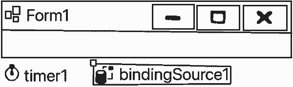

Рис. 3.1. Форма и панель компонентов.

Некоторые элементы управления, которые наследуют класс Control, отображаются на панели компонентов, но не отображаются на форме. К ним относятся, например, контейнеры пунктов меню (главного и контекстного), инструментов и элементов строки состояния. В форме отображаются только коллекции этих контейнеров. **Кроме элементов** управления, пространство имен System.Windows.Forms предоставляет классы, которые не являются производными от класса Control, но также обеспечивают визуальные функции для приложений Windows. **Ряд элементов** управления являются контейнерами, предназначенными для хранения других элементов управления. К таким контейнерам относятся Panel, GroupBox и др. Главным контейнером элементов управления является форма, представленная классом Form. Все элементы управления, размещенные на форме, сохраняются в её коллекции. Не отображаемые элементы, то есть компоненты, в коллекцию формы не добавляются. **B Visual Studio** все элементы пользовательского интерфейса перечислены в окне «Панель элементов». В этом окне элементы представлены в общем отсортированном списке (Все формы Windows. Forms), а также разбиты на группы по категориям (см. рис. 3.2).

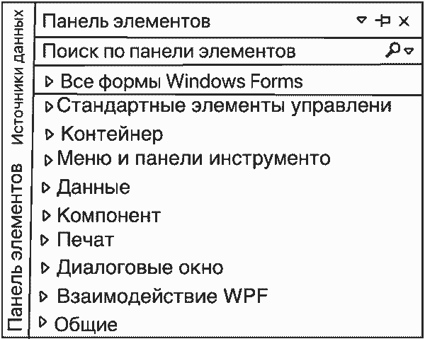

Рис. 3.2. Вкладка «Панель элементов».

В некоторых группах находятся как отображаемые, так и неотображаемые элементы. Например, в группе «Данные» есть отображаемый элемент управления DataGridView и неотображаемый компонент BindingSource. **Общим термином** для элементов управления и компонентов в данном учебнике будет «элемент». **К стандартным** элементам управления (см. рис. 3.3) относятся традиционные элементы, например Label и Button. Они отображают данные и управляют вычислительным процессом. **Контейнеры (см. рис. 3.4)** — это элементы управления, объединяющие другие элементы управления и выполняющие в основном вспомогательные функции.

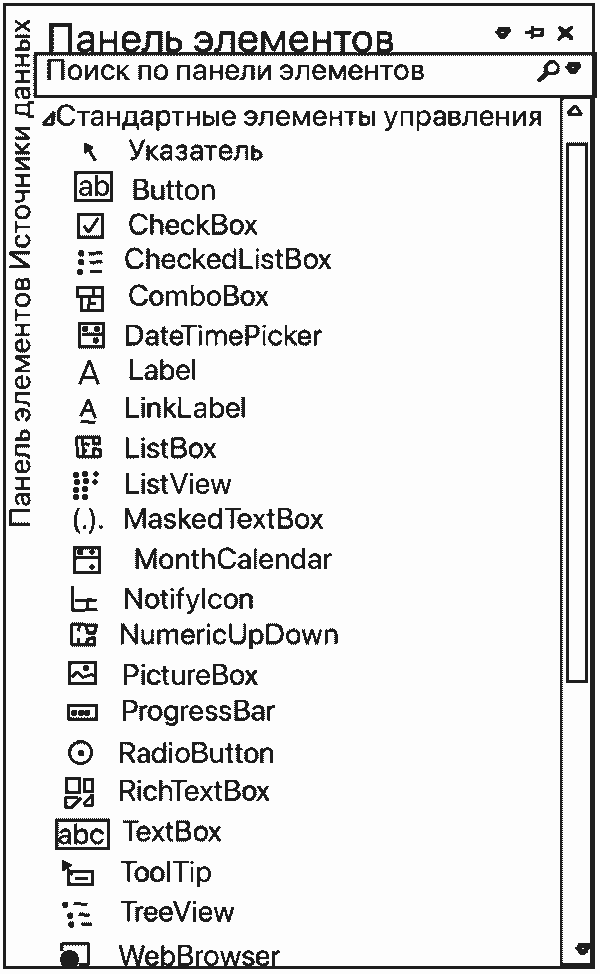

Рис. 3.3. Стандартные элементы управления.

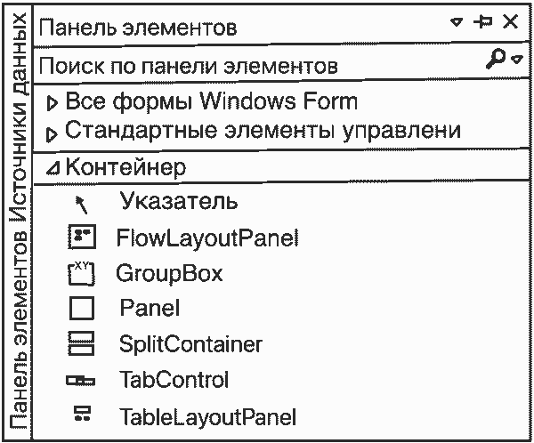

Рис. 3.4. Контейнеры.

Главное меню (MenuStrip), контекстное меню (ContextMenu) и панели инструментов (ToolStrip) представлены в группе «Меню и панели инструментов» (см. рис. 3.5). К этой же группе относится и элемент управления «Строка состояния», представленный классом StatusStrip. Особенностью этих элементов является то, что содержимое их контейнеров отображается в форме, а сами элементы отображаются на панели компонентов. Кроме того, полоска главного меню и строка состояния наследуют класс ToolStrip, поэтому все эти элементы управления находятся в одной группе. Для отображения данных в табличном виде или в виде диаграммы используются элементы управления из группы «Данные» (см. рис. 3.6). Основным и наиболее сложным элементом управления является DataGridView. Об этом элементе можно написать отдельную книгу. Элементы BindingSource и DataSet являются компонентами.

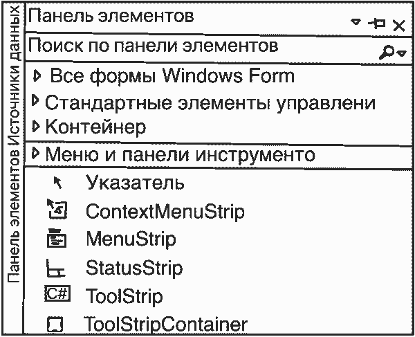

Рис. 3.5. Меню и панели инструментов.

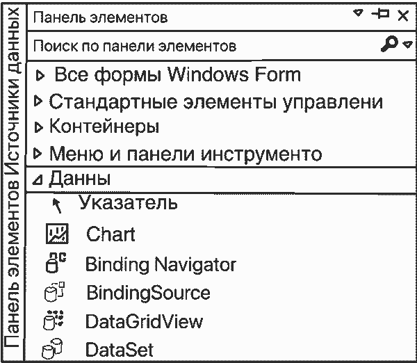

Рис. 3.6. Группа «Данные»

Группа «Компоненты» (см. рис. 3.7) представлена элементами интерфейса, которые не имеют рисунка, отображаемого на форме. Эти компоненты, в отличие от элементов управления, не наследуют класс Control. Часто используемым компонентом является Timer.

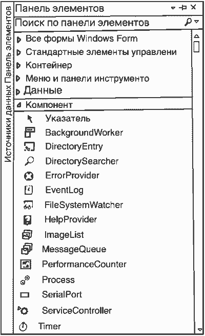

Рис. 3.7. Группа «Компоненты»

Компоненты, относящиеся к печати, выделены в отдельную группу (см. рис. 3.8). Во время выполнения программы они отображаются в виде диалоговых окон.

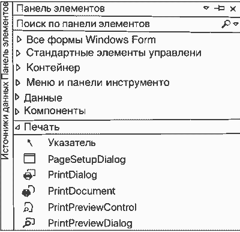

Рис. 3.8. Компоненты печати.

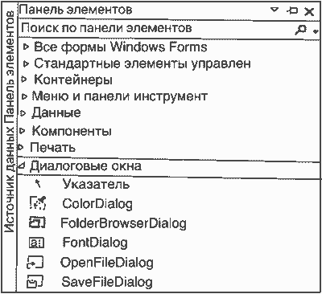

Рис. 3.9. Диалоговые окна.

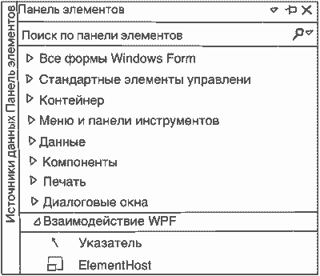

Рис. 3.10. Группа «Взаимодействие WPF»

Элементы управления можно разделить на группы по нескольким признакам. Например, отдельные элементы управления являются управляющими, другие предназначены для хранения и отображения информации. Есть простые элементы управления и сложные. Сложные элементы — это элементы, имеющие коллекции объектов. Часто для заполнения коллекции объектами используется привязка элемента управления к источнику данных. Также элементы управления можно разделить на простые в освоении и трудные, часто используемые (традиционные) и редко. Основным классом пространства имен System.Windows.Forms является класс Form, представляющий окно приложения. Окна бывают родительскими и дочерними, модальными и немодальными. В пространстве имен System.Windows.Forms имеется ряд типов, обеспечивающих поддержку вышеупомянутых элементов управления и компонентов. Примерами вспомогательных типов могут служить перечисления, делегаты и классы аргументов обработчиков событий. Не все элементы управления и компоненты отображаются на панели элементов. Вы можете их добавить, открыв окно «Выбор элементов панели элементов» (см. рис. 3.11). Для этого щелкните правой кнопкой мыши на панели. Например, Вы можете добавить старый, но по-своему интересный элемент DataGrid.

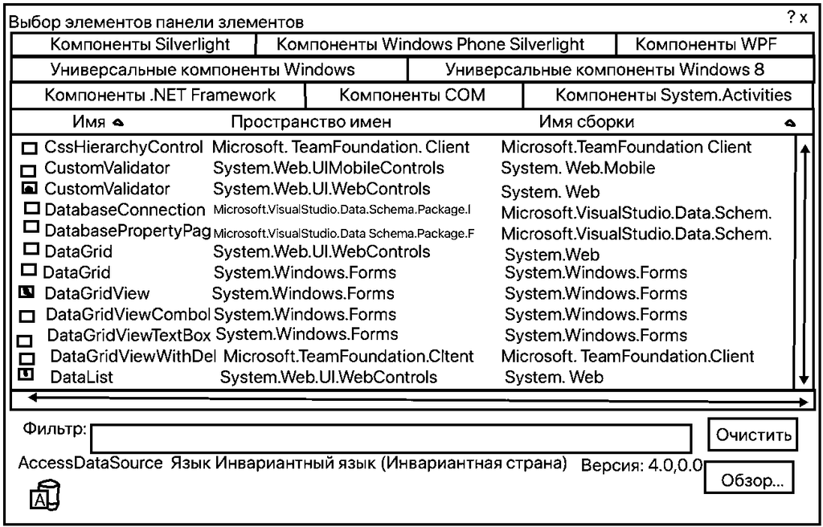

Рис. 3.11. Выбор элементов панели элементов.

Ряд свойств являются внешними. Такие свойства, если они не заданы, получают значение из родительского элемента управления. Например, объект Button по умолчанию будет иметь то же свойство BackColor, что и его родительский объект Form. К внешним свойствам относятся Cursor, Font, BackColor, ForeColor и RightToLeft. Окно свойств отображает важное свойство, относящееся к конструктору Visual Studio, — это Modifiers. Данное свойство определяет уровень видимости элемента. Обычно все элементы определяются в файле $Form_x$.Designer.cs с модификатором доступа private, но если Вы хотите получить доступ к элементу управления за пределами класса $Form_x$, в котором они определены, то выберите из списка значение public. При выделении отдельных элементов управления в их правом верхнем углу появляется кнопка со значком смарт-тега (IDI). Эта кнопка дает более высокий уровень настройки элемента управления по сравнению с окном свойств. Для многих элементов управления по щелчку смарт-тега отображается диалоговое окно с наиболее часто используемыми свойствами для их настройки (см. рис. 3.12). Для ряда элементов управления выводится окно для выполнения привязки элемента к источнику данных. У сетки DataGridView отображаются некоторые окна для её настройки, которые через окно свойств получить нельзя.

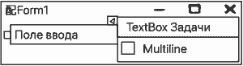

Рис. 3.12. Использование смарт-тега.

Далее рассмотрим базовую функциональность элементов управления, реализуемую классом Control.

# 4. ЧАСТО ИСПОЛЬЗУЕМЫЕ ЧЛЕНЫ КЛАССА Control.

### 4.1. Свойства класса Control.

- Text — текст, отображаемый в элементе управления.
- Font — шрифт текста.
- ForeColor — цвет переднего плана элемента управления, то есть текста.
- BackColor — цвет фона элемента управления. Свойство BackColor не поддерживает прозрачные цвета, если значение SupportsTransparentBackColor объекта ControlStyles не равно true.
- BackgroundImage — графический образ для фона элемента управления, например какой-либо рисунок.
- BackgroundImageLayout — способ отображения графического образа в элементе управления. Возможные значения: Center, None, Stretch, Tile или Zoom. Tile является значением по умолчанию.
- Cursor — вид курсора, отображаемого, когда указатель мыши находится на элементе управления.

К категории «Макет» относятся следующие свойства:

- Anchor (якорь) — прикрепляет элемент управления на постоянном расстоянии от заданных граней контейнера, которому принадлежит этот элемент. В качестве контейнера могут выступать форма (объект типа Form), элементы GropBox, Panel и др.

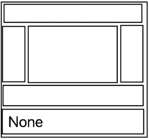

Рис. 4.2. Грани родительского элемента.

Грани контейнера соответствуют следующим значениям: Top, Bottom, Left, Right. По умолчанию задаются значения Top и Left. Dock — определяет, к какой грани родительского элемента должен пристыковываться данный элемент (см. рис. 4.2). Грани родительского элемента соответствуют следующим значениям: None, Top, Bottom, Right, Left, Fill. По умолчанию используется значение None.

- **Location** - задает или возвращает значение структуры Point с координатами Х и У левого верхнего угла элемента управления относительно левого верхнего угла контейнера.
- **Size** — структура. Возвращает или задает высоту и ширину элемента управления. Поля структуры — Width (ширина) и Hight (высота).
- **Поведение** элемента управления определяют следующие свойства:
- **AllowDrop** — возвращает или задает значение, указывающее, может ли элемент управления принимать данные, перетаскиваемые в него пользователем.
- **Enabled** — возвращает или задает значение, показывающее, доступен (true) ли элемент управления (и все его дочерние элементы) пользователю. Недоступный (false) элемент управления отображается менее ярко, чем доступный.
- **Visible** - позволяет сделать элемент управления (и все его дочерние элементы) видимым (true) или невидимым (false).
- **TabIndex** — порядковый номер элемента управления в последовательности перемещения по клавише Tab. Для изменения порядковых номеров элементов управления на форме можно воспользоваться меню Вид → Последовательность перехода.
- **TabStop** — получает или задаст значение, показывающее, можно ли перевести фокус на данный элемент управления при помощи клавиши ТАВ.
- **TabStop** — получает или задает значение, показывающее, можно ли перевести фокус на данный элемент управления при помощи клавиши ТАВ.
- **ContextMenuStrip** - связывает элемент управления с контекстно-зависимым меню.

Другие свойства: **Name** — имя элемента управления. Как правило, разработчик большой программы изменяет это имя на понятное, так как такие имена, как button1, button2, textBox1 и т. д., не описывают назначение соответствующего элемента управления. В Visual Studio значение свойства Name совпадает с именем ссылки на объект. Поскольку свойство Name возвращает тип String, с ним можно выполнять строковые операции, например, для определения с помошью оператора switch, какому элементу принадлежит данное имя. Класс Control содержит также множество неотображаемых в окне свойств. Например.:

- **CanFocus** - получает значение, показывающее, может ли элемент управления получать фокус.
- **CanSelect** - получает значение, показывающее, доступен ли элемент управления для выбора.

# 4.2. Методы класса Control

К наиболее часто используемым методам элементов управления относятся следующие: **Focus** — метод задает фокус ввода элемента управления. Такой элемент становится выделенным, и курсор устанавливается в строке ввода (перед текстом), если элемент допускает ввод. Метод Focus является часто используемым методом. Синтаксис метода Focus: `public bool Focus()`. Метод возвращает true, если элемент управления успешно получил фокус ввода, в противном случае — false.

В следующем примере фокус передается элементу control при условии, что он имеет возможность получать фокус. Методу можно передавать ссылку на любой элемент управления, если он наследует класс Control.

```
public void ControlSetFocus(Control control)
{
    // Передать фокус элементу, если он его поддерживает.
    if(control.CanFocus)
        control.Focus();
}
```

- **FindForm** — Получает форму, в которой находится элемент управления. Синтаксис метода FindForm: `public Form FindForm()`
- **Refresh** — Принудительно создаст условия, при которых элемент управления делает недоступной свою клиентскую область и немедленно перерисовывает себя и все дочерние элементы. Метод применяется для отображения данных в элементе управления, которые на текущий момент времени по тем или иным причинам не были отображены. При переопределении метода Refresh в производном классе следует вызвать метод Refresh базового класса, чтобы элемент управления и его дочерние элементы стали недопустимыми и были перерисованы. Синтаксис метода Refresh: `public virtual void Refresh()`
- **ResetBindings** - вызывает в элементе управления, привязанном к компоненту BindingSource, повторное считывание всех элементов списка и обновление их отображаемых значений. Синтаксис метода ResetBindings: `public void ResetBindings)`
- **GetNextControl** - извлекает следующий или предыдущий олемент управления в последовательности табуляции дочерних алементов управления.
- **Select** - активирует элемент управления.Синтаксис метода Select: `public void Select()`
- **Update** - вызывает перерисовку элементом управления недопустимых областей клиентской области. Метод выполняет все отложенные запросы на рисование, поэтому он в первую очередь используется в задачах на вывод графики.

# 4.3. События класса controi

К наиболее часто используемым событиям элементов управления относятся следующие:

- **Click** — происходит при щелчке элемента управления.
- **DoubleClick** - происходит, когда элемент управления дважды щелкается.
- **Enter** — происходит при входе в элемент управления (при получении фокуса ввода). События Enter и Leave подавляются классом Form. В классе Form им эквивалентны события Activated и Deactivate.

В следующем примере событие Enter используется для изменения цветов текста и фона объекта TextBox, когда этот элемент получает фокус ввода.

```
Color fc, bc;
// Поля для хранения текущих цветов.
private void textBox1_Enter(object sender, System.EventArgs e)
{
    // Если поле ТехВох а не пустое,
    // тогда изменить цвет фона и текста.
    if (textBox1.Text != String.Empty)
    {
        // Запомнить текущие цвета.
        fc = textBox1.ForeColor;
        bc = textBox1.BackColor;
        // Изменить цвет текста и фона.
        textBox1.ForeColor = Color.Red;
        textBox1.BackColor = Color.Black;
    }
}
```

**Leave** — происходит, когда фокус ввода покидает элемент управления. В следующем примере, связанном с предыдущим, событие Leave используется для восстановления цветов текста и фона объекта TextBox, когда этот элемент теряет фокус ввода.

```
private void textBox1_Leave(object sender, System.EventArgs e)
{
    // Восстановить цвет текста и фона.
    textBox1.ForeColor = fc;
    textBox1.BackColor = bc:
}
```

- **KeyPress** — происходит при нажатии клавиши, если элемент управления имеет фокус. Событие KeyPress вызывается только нажатием клавиш с символами. Нажатие остальных клавиш вызывает события KeyDown и KeyUp.
- **GotFocus** — генерируется при получении фокуса элементом управления.
- **TextChanged** — происходит при изменении значения свойства Text.
- **Validate** — происходит при проверке элемента управления. Как правило, проверяется значение свойства Text или Value, когда ввод текста завершен, то есть элемент теряет фокус.

Отдельные события чаще всего используются для конкретных элементов. Например, событие TextChanged используется преимущественно для элементов управления, имеющих поле ввода. К таким элементам относятся TextBox, RichTextBox, ComboBox и др. События мыши и клавиатуры используются в основном при работе с графикой. **Несмотря** на то что класс Control определяет большое количество событий, многие элементы, наследуя базовые события этого класса, как правило, переопределяют их или добавляют новые. **Например**, элемент управления DataGridView (сетка) определяет порядка двухсот событий, из которых многие — это уникальные события сетки. Отсюда следует, что знаний только событий класса Control для разработки больших проектов явно недостаточно. **Параметры** обработчика события. Рассмотрим подробнее параметры обработчика события на примере событий Click и KeyPress для кнопки (button1) и текстового поля (textBox1):

```
private void button1_Click (object sender, EventArgs e) {/*...*/}
private void textBox1_KeyPress(object sender, KeyPressEventArgs e) {/*...*/}
```

# 5. ВНЕДРЕНИЕ ИЗОБРАЖЕНИЯ В СБОРКУ.

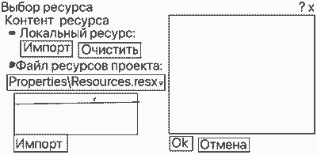

Рис. 5.1. Окно выбора ресурса.

На этапе разработки локальный файл ресурсов представляется resx-файлом формы, например Form1.resx, а файл ресурсов проекта — resx-файлом `Properties\Resources.resx`.

Представление данных в виде ресурсов — распространенная практика, используемая в языке C#. Например, все строковые константы программы сохраняются в виде ресурсов. Если стоит задача отобразить какое-либо изображение из файла или нарисовать рисунок графическими средствами Windows.Forms, то для этих целей может подойти элемент управления Panel, однако лучше использовать элемент управления PictureBox, так как он оптимизирован для рисования.

# 6. ДИАЛОГОВОЕ ОКНО MessageBox.

Очень часто возникает необходимость в выводе пользователю какого-либо сообщения или предложения сделать выбор. Для этих целей разработан класс MessageBox, который с помощью статического метода Show осуществляет вывод специального диалогового окна (см. рис. 6.1). В учебнике мы будем использовать это окно для вывода отладочной информации и информации об ошибках.

```
Вы забыли ввести значение в текстовое поле 'Сумма в рублях. Х
    OK
```

Рис. 6.1. Стандартное окно сообщения.

Окно сообщения является модальным окном, то есть это окно не даёт пользователю переключиться на другие окна текущего приложения, пока пользователь не закроет модальное окно. Диалоговые окна бывают двух типов: окно сообщения, не предлагающее какой-либо выбор (окно с одной кнопкой ОК, см. рис. 6.1), и окно с несколькими кнопками, предлагающими выбор (см. рис. 6.2). В последнем случае разработчик, как правило, анализирует возвращаемую окном информацию о нажатой пользователем кнопке.

```
Сделайте выбор
Продолжить выполнение программы?
    Да  Нет
```

Рис. 6.2. Диалоговое окно сообщения с выбором ответа.

На рис. 6.2 показан более эргономичный вариант окна: с заголовком и значком вопроса. Для отображения окна в том или ином формате класс MessageBox содержит 21 перегруженную версию метода Show. Рассмотрим простейшую перегрузку этого метода, используемую только для информирования пользователя. Синтаксис метода Show:

```
public static MessageBoxResult Show(string messageBoxText)
```

Параметр messageBoxText определяет строку с отображаемым в окне текстом. Несмотря на то что данная перегрузка возвращает ответ, его никогда не анализируют, так как такое окно содержит только одну кнопку ОК (кнопка Close возвращается как кнопка ОК) и никакого другого выбора сделать нельзя. В нижеприведенном примере показан вызов метода Show, который выводит окно, представленное на рис. 6.1.

```
MessageBox.Show("Вы забыли ввести значение в текстовое поле Сумма в рублях");
```

В качестве следующей версии метода show мы выберем наиболее информативную. Синтаксис метода show:

```
public static MessageBoxResult Show(
    string messageBox Text
    , string caption
    , MessageBoxButton button
    , MessageBoxImage icon
)
```

Эта перегрузка может отобразить значок и несколько кнопок для выбора. В следующем примере показан фрагмент кода с версией метода Show, выводящего окно, представленное на рис. 6.2.

```
DialogResult res = MessageBox.Show (
    "Продолжить выполнение программы?"
    , "Сделайте выбор"
    , MessageBoxButtons.YesNo
    , MessageBoxIcon.Question
);
if (res == DialogResult.No) Close();
```

Обратите внимание: в примере определены кнопки Yes, No, а в окне они отображаются как «Да» и «Нет». Это связано с настройками Windows на русский язык.

Типы DialogResult, MessageBoxButtons и MessageBoxIcon — это перечисления. Их значения очевидны, поэтому здесь они не описываются.

# 7. ПРОГРАММНОЕ УПРАВЛЕНИЕ ИНТЕРФЕЙСОМ.

Довольно-таки часто в Windows-приложениях предполагается, что элементы управления следует выбирать в некоторой последовательности, нарушать которую нельзя. Например, предположим, что в нашем приложении, осуществляющем конвертирование рублей в доллары, нужно вычислить некоторую комиссию, удерживаемую за проведение операции. Добавим текстовое поле для ввода процентов, кнопку «Удержать комиссию» и текстовое поле для отображения итоговой суммы, выдаваемой клиенту. Получим окно, представленное на рис. 7.1.

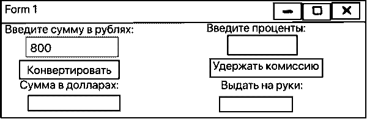

Рис. 7.1. Форма с удержанием комиссии.

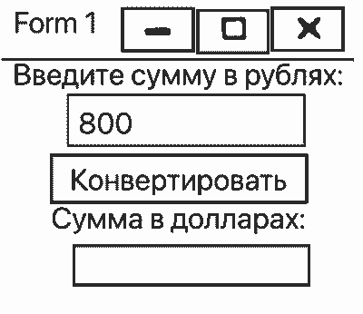

После нажатия кнопки «Конвертировать» и успешного вычисления суммы в долларах недоступные элементы следует сделать доступными. Это уже мы сделаем программным способом в обработчике button1_Click:

```
private void button1_Click(object sender, EventArgs e)
{
    float rubli, dollars;
    if (
        !float. TryParse(textBox1.Text, out rubli)
        || rubli <= 0
        || rubli > = 100000
    )
    {
        MessageBox.Show("Неправильно введена сумма в рублях!");
         textBox1.Focus();
         return;
    }
    dollars = rubli / curs;
    textBox2.Text = dollars.ToString();
    label3.Enabled = true;
    textBox3.Enabled = true;
    button2.Enabled = true;
    label4.Enabled = true;
    textBox4.Enabled = true;
}
```

А если мы, не закрывая окно, вводим новую сумму, то элементы управления, расположенные справа, снова надо сделать недоступными. Реализуем это в обработчике textBox1.TextChanged:

```
private void textBox1_TextChanged (object sender, EventArgs e)
{
    if (label3.Enabled == false) return;
    label3.Enabled = false;
    textBox3.Enabled = false;
    button2.Enabled = false;
    label4.Enabled = false;
    textBox4.Enabled = false;
}
```

Итак, мы рассмотрели общие свойства, методы и события, научились управлять доступностью элементов управления. Для того чтобы побыстрее начать разработку Windows-приложений, рассмотрим элементы управления, наиболее часто используемые в пользовательских интерфейсах.